# concept_3_2

## ECON 0150 | Economic Data Analysis

The economist’s data analysis skillset.

### *Part 3.2 | Sampling and the Central Limit Theorem*

## A Big Question

If all we see is the sample, how do we learn about a population?

- In general, a population’s random variables will be unobservable.
- If we only see a sample, what *can* we say about the population?

## Random Variables: Known

If we know the random variable, we can learn many things about the population.

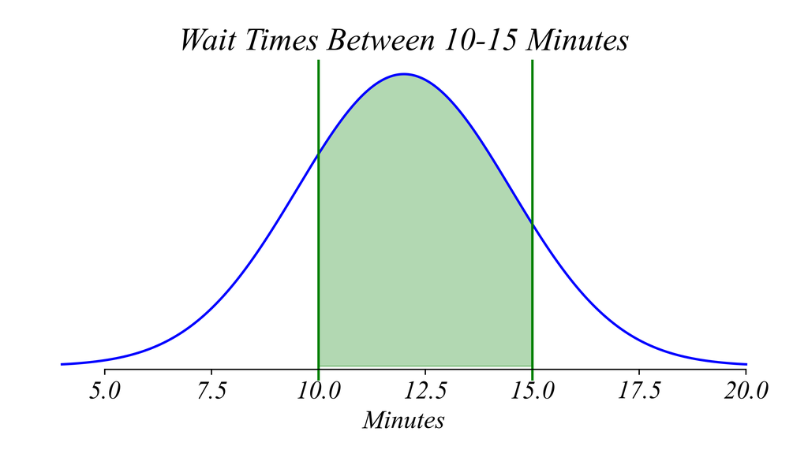

*> when we know the probability function, we can calculate everything exactly*

## Random Variables: Known

If we know the random variable, we can learn many things about the population.

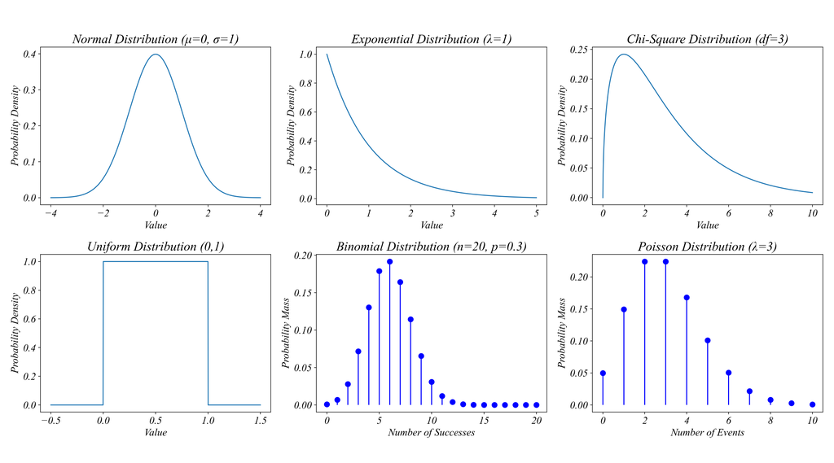

*> but what can we know about the population if we only see the sample?*

## Random Variables: Unknown

But if all we see is the sample, what can we know about a population?

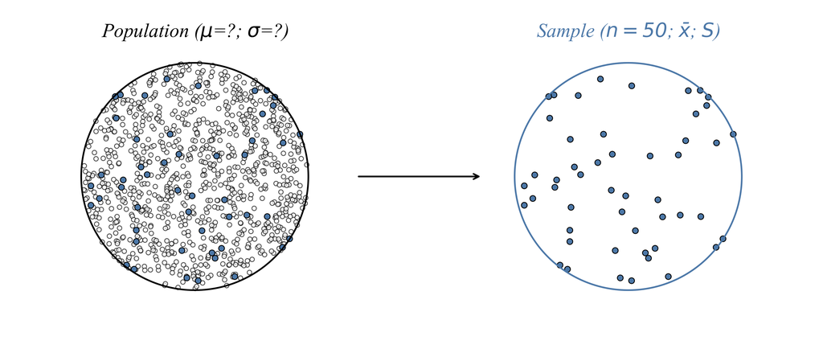

*> how do we learn about $\mu$ if all we have is $n$, $\bar{x}$, and $S$?*

## Exercise 3.2 | Sampling Dice (n=1)

Let’s pretend we don’t know the probability function for dice.

Let’s start with something simple.

1. Roll a die once (sample size: n=1).
2. We’ll plot the distribution of our samples.

## Exercise 3.2 | Results (n=1)

Your samples have a lot of variability!

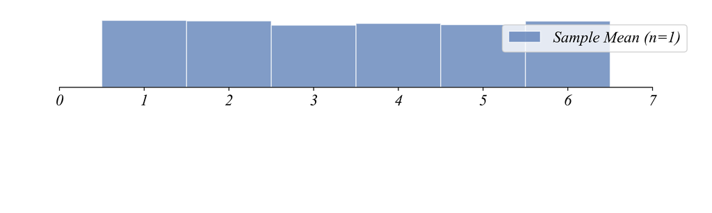

## Exercise 3.2 | Sampling Dice (n=2)

Now take a sample of two rolls and compute the mean.

Next is something slightly less boring.

1. Roll a die twice (sample size: n=2).
2. Calculate the mean of your two rolls.
3. We’ll plot the distribution of your sample means.

## Exercise 3.2 | Results (n=2)

Each sample has a slightly different sample mean.

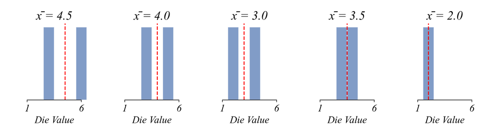

*> there’s a lot of variability in your sample means!*

*> what do you expect to see when we plot these sample means ($\bar{x}$)?*

## Exercise 3.2 | Results (n=2)

The distribution of sample means bunches in the middle.

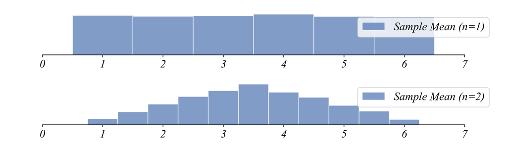

*> our sample means are more bunched (like a pyramid) in the middle! why?*

*> there are more ways to get 7/2 than 2/2!*

## Exercise 3.2 | Sampling Dice (n=3)

Now take a sample of three rolls and compute the mean.

Next is something even less boring.

1. Roll a die three times (sample size: n=3).
2. Calculate the mean of your three rolls.
3. We’ll plot the distribution of your sample means.

## Exercise 3.2 | Results (n=3)

The distribution of sample means with n=3.

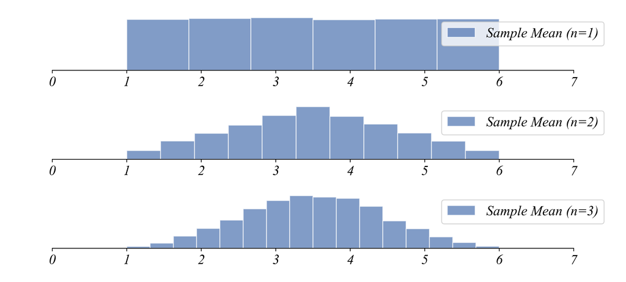

*> what do you notice about the shape with n=3?*

## Exercise 3.2 | Results (n=3)

The distribution of sample means with n=3.

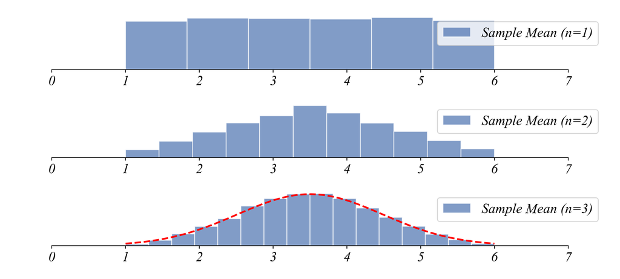

*> there’s some curvature to the shape, and the edges are rounding into a curve*

## Exercise 3.2 | Sampling Dice (n=30)

Now let’s really increase the sample size.

Next is something very un-boring.

1. Roll a die thirty times (sample size: n=30).
2. We’ll simulate this 1,000 times and plot the distribution of sample means.

## Exercise 3.2 | Results (n=30)

Your individual samples each look different.

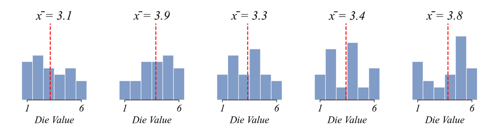

*> there are even more ways your sample could look!*

*> what do you expect to see when we plot these sample means ($\bar{x}$)?*

## Exercise 3.2 | Results (n=30)

What happens when we really increase the sample size?

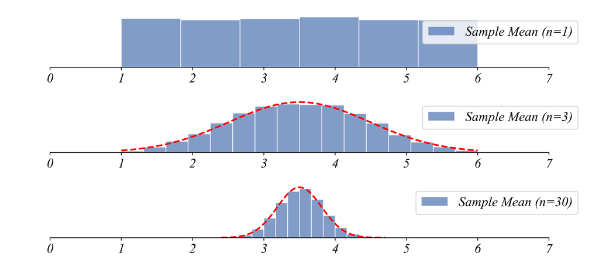

*> the distribution of sample means gets tighter and more bell-shaped*

## Exercise 3.2 | Results (n=30)

What happens when we really increase the sample size?

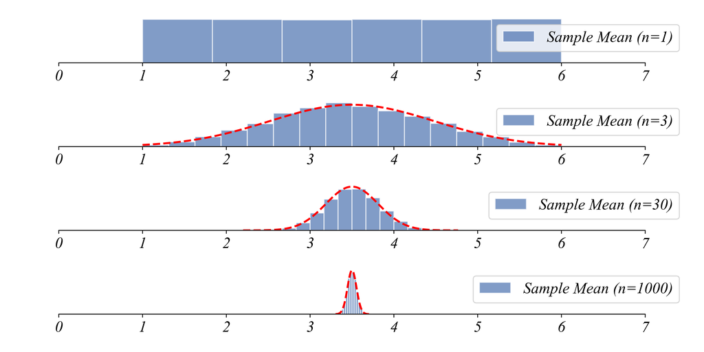

*> what is this probability function in red?*

## The Central Limit Theorem

The distribution of sample means approximates a normal distribution as sample size increases.

$$\bar{x} \xrightarrow{d} N\Big(\mu, \frac{\sigma}{\sqrt{n}}\Big)$$

1. **Shape**: the sampling distribution converges to normal
2. **Center**: it’s centered on the population mean $\mu$
3. **Spread**: the standard error $\sigma/\sqrt{n}$ shrinks with larger $n$

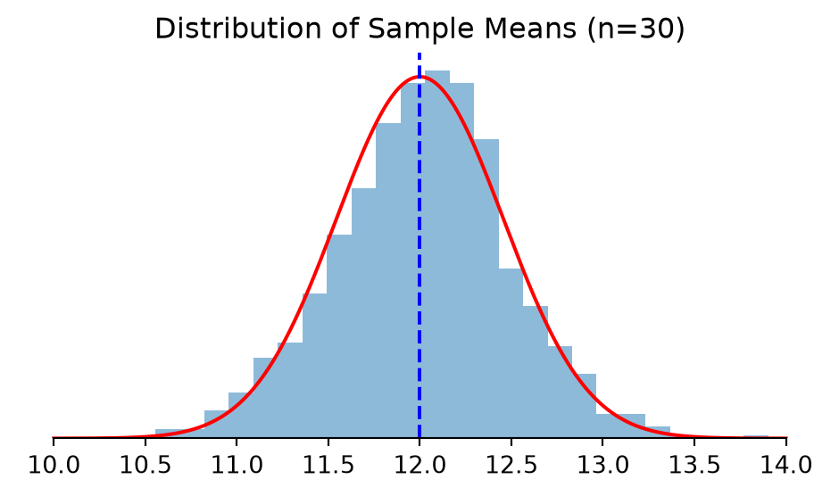

## The Standard Error

Where does $\sigma / \sqrt{n}$ come from?

Each observation $x_i$ is drawn independently with variance $\sigma^2$, so:
$$Var(x_1 + x_2 + \cdots + x_n) = n\sigma^2$$

Dividing by $n$ divides the variance by $n^2$:
$$Var\Big(\frac{x_1 + x_2 + \cdots + x_n}{n}\Big) = \frac{n\sigma^2}{n^2} = \frac{\sigma^2}{n}$$

Take the square root:
$$SD(\bar{x}) = \sqrt{\frac{\sigma^2}{n}} = \frac{\sigma}{\sqrt{n}}$$

## Skewed Distributions

Does the CLT work for distributions that aren’t as nice?

**Question**: *Does the CLT still work when the population looks asymmetric?*

## Exercise 3.2 | Skewed Population

Simulate 1,000 sample means from a chi-squared population with n=1.

```python
# Simulate 1000 sample means from a skewed population
samples = stats.chi2.rvs(df=3, size=(1000, 1))
sample_means = samples.mean(axis=1)
sns.histplot(sample_means, bins=30)
```

*> with n=1, the sample means are just the raw observations*

## Exercise 3.2 | Skewed Population (n=1)

The distribution of sample means looks just like the population: very skewed.

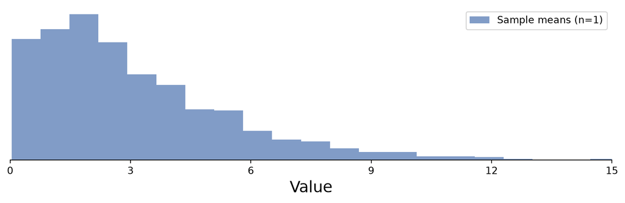

*> now increase the sample size to n=5*

## Exercise 3.2 | Skewed Population (n=5)

The skew is already diminishing.

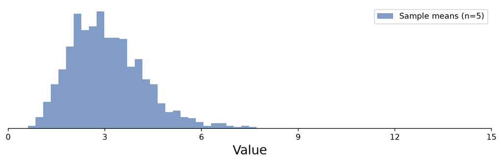

*> now increase to n=30*

## Exercise 3.2 | Skewed Population (n=30)

It looks normal, despite the skewed population.

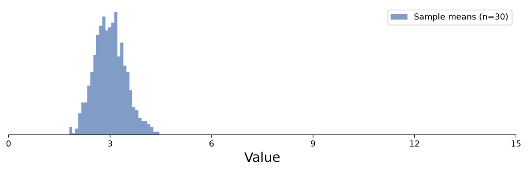

*> now increase to n=1000*

## Exercise 3.2 | Skewed Population (n=1000)

Very tight, very normal.

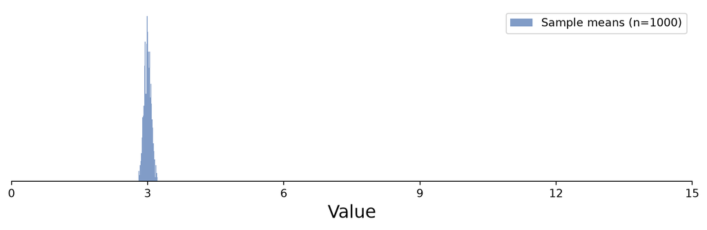

*> the skew has completely disappeared*

## Exercise 3.2 | Skewed Population

Overlay the n=1 distribution behind the n=1000 distribution.

```python
# Overlay n=1 (raw population) behind n=1000 (tight, normal)
means_1 = stats.chi2.rvs(df=3, size=(1000, 1)).mean(axis=1)
means_1000 = stats.chi2.rvs(df=3, size=(1000, 1000)).mean(axis=1)

sns.histplot(means_1, bins=30, alpha=0.3, stat='density', label='Sample means (n=1)')
sns.histplot(means_1000, bins=30, alpha=0.7, stat='density', label='Sample means (n=1000)')
```

## Exercise 3.2 | Skewed Population

From skewed population to normal sampling distribution.

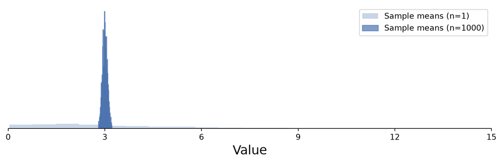

*> the CLT works for (nearly) any distribution shape*

## Exercise 3.2 | Skewed Population

The full picture: sample means converge to normal as n increases.

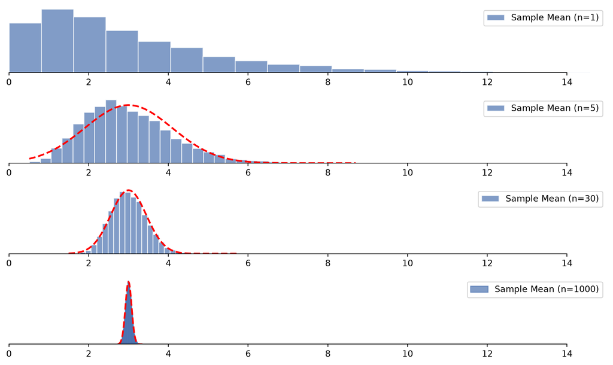

## Key Properties

Three things to notice about the sampling distribution of $\bar{x}$.

1. **Unbiased**: the sampling distribution is centered on the population mean $\mu$.
2. **Precise**: the standard error $\sigma/\sqrt{n}$ shrinks as sample size increases.
3. **Universal**: the shape approaches normal regardless of the population.

## Assumptions

The CLT isn’t magic. There are a few conditions.

1. **Independence**: observations don’t influence each other.
2. **Identical distribution**: observations come from the same population.
3. **Sample size**: $n \geq 30$ is usually sufficient.

## What We’ve Achieved

From an unobservable population to a knowable sampling distribution.

1. **Problem**: the population distribution is unobservable.
2. **Insight**: the distribution of $\bar{x}$ is knowable even when the population isn’t.
3. **Implication**: that distribution is centered on $\mu$, linking sample to population.

## Looking Ahead

We know the sampling distribution. Now what do we do with it?

- Part 3.3 | **Confidence Intervals** - how close is $\bar{x}$ to the true $\mu$?
- Part 3.4 | **Hypothesis Testing** - can we test whether $\mu$ equals a specific value?

*> the CLT gives us the distribution; Parts 3.3 and 3.4 show us how to use it*